# Assignment 5 - K-means

Author

Liming Zhou

# 1 Goal of this assignment

The goal of this assignment is for you to **explore the k-means algorithm** learned in class.

In specific, you will be asked to:  
- Use a different number of k than what we did in class,  
- Validate the results of the new model, and  
- Compare your results with those found in class

# 2 Instructions

You will first need to watch (and code along with) the following k-means video:

- k-means lab: https://youtu.be/GFgMp5tYiMU?si=CI0E-2r-cYZLGVL1 (start from beginning of video, watch till the 01:10)
- The partial script for the video above is in our GitHub repository, 04-classcode, **02-24_multivar_kmeans_partial.qmd**. Move the script mentioned above into the `code` subfolder of your `06_multivar` project

**AFTER watching the video and developing the code in class**, then start working on this HW assignment (instructions below): - Move this script into the `code` subfolder of your `06_multivar` project  
- On this script, fill your name under the `title` section of the YAML  
- Go back to the class k-means script, choose a different number of k than what we did in class, and run it.

# 3 Questions

## 3.1 1. What number of k did you select? Why?

```r
library(tidyverse)
library(ggcorrplot)
library(broom)
library(car)
library(factoextra)
library(ggpmisc)
weather<- read_csv("../data/weather_monthsum.csv")
weather_n <- weather %>%
  dplyr::select(-c(year:strength_gtex))

weather_n
```

```
# A tibble: 698 × 72
   mean_dayl.s_Jan mean_srad.wm2_Jan mean_tmax.c_Jan mean_tmin.c_Jan
             <dbl>             <dbl>           <dbl>           <dbl>
 1          35873.              242.            10.2            -1.5
 2          35743.              215.             9.2             0.2
 3          36359               279.            13.4            -2.4
 4          36420.              240.            13.9             2.9
 5          37494.              277             19.9             7.2
 6          35873.              224.             9.7             0.7
 7          36451.              221.            13.2             3.2
 8          35760.              244              9.5            -1.8
 9          35678.              265.             5.8            -5.8
10          36941.              254             15.8             5.6
# ℹ 688 more rows
# ℹ 68 more variables: mean_vp.pa_Jan <dbl>, sum_prcp.mm_Jan <dbl>,
#   mean_dayl.s_Feb <dbl>, mean_srad.wm2_Feb <dbl>, mean_tmax.c_Feb <dbl>,
#   mean_tmin.c_Feb <dbl>, mean_vp.pa_Feb <dbl>, sum_prcp.mm_Feb <dbl>,
#   mean_dayl.s_Mar <dbl>, mean_srad.wm2_Mar <dbl>, mean_tmax.c_Mar <dbl>,
#   mean_tmin.c_Mar <dbl>, mean_vp.pa_Mar <dbl>, sum_prcp.mm_Mar <dbl>,
#   mean_dayl.s_Apr <dbl>, mean_srad.wm2_Apr <dbl>, mean_tmax.c_Apr <dbl>, …
```

```r
# normalizing the data
weather_norm  <- weather_n %>%
  mutate(across(everything(),~scale(.x)))

weather_norm
```

```
# A tibble: 698 × 72
   mean_dayl.s_Jan[,1] mean_srad.wm2_Jan[,1] mean_tmax.c_Jan[,1]
                 <dbl>                 <dbl>               <dbl>
 1             -0.699                 -0.962            -0.904
 2             -0.905                 -1.96             -1.15
 3              0.0762                 0.365            -0.116
 4              0.174                 -1.07              0.00688
 5              1.89                   0.285             1.48
 6             -0.699                 -1.64             -1.03
 7              0.222                 -1.73             -0.165
 8             -0.879                 -0.905            -1.08
 9             -1.01                  -0.151            -1.99
10              1.00                  -0.544             0.475
# ℹ 688 more rows
# ℹ 69 more variables: mean_tmin.c_Jan <dbl[,1]>, mean_vp.pa_Jan <dbl[,1]>,
#   sum_prcp.mm_Jan <dbl[,1]>, mean_dayl.s_Feb <dbl[,1]>,
#   mean_srad.wm2_Feb <dbl[,1]>, mean_tmax.c_Feb <dbl[,1]>,
#   mean_tmin.c_Feb <dbl[,1]>, mean_vp.pa_Feb <dbl[,1]>,
#   sum_prcp.mm_Feb <dbl[,1]>, mean_dayl.s_Mar <dbl[,1]>,
#   mean_srad.wm2_Mar <dbl[,1]>, mean_tmax.c_Mar <dbl[,1]>, …
```

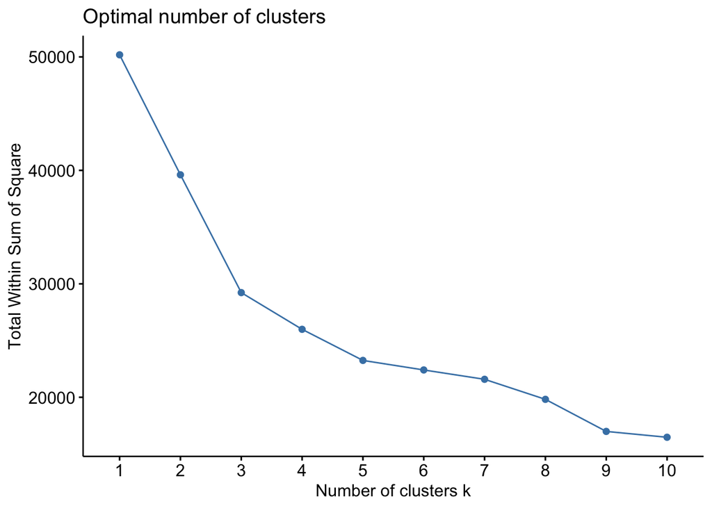

```r
# try to check the number of k-menas
fviz_nbclust(weather_norm,
             method = "wss", # within the sum of squares
             k.max = 10,
             FUNcluster = kmeans
             )
```

```r
# let's try 9 here. Because I want to make this (between_SS / total_SS =  66.1 %) higher, but not to less efficient.
mod_km9 <- kmeans(weather_norm,
                  centers = 9,
                  nstart = 10
                  )

mod_km9
```

```
K-means clustering with 9 clusters of sizes 118, 90, 44, 103, 152, 74, 56, 45, 16

Cluster means:
  mean_dayl.s_Jan mean_srad.wm2_Jan mean_tmax.c_Jan mean_tmin.c_Jan
1      0.32841708         1.1861877      0.30319518     -0.60442405
2      0.71040998         0.0117974      0.42766650      0.60950584
3     -0.01866536         0.4210056      1.38803092      0.90849539
4     -1.16699371        -1.1572578     -1.22118580     -0.60224146
5     -0.01828244        -0.5396709     -0.22850173      0.04738694
6     -0.49069892         0.1972581     -0.58175458     -0.99819771
7      2.38609071         1.1248966      1.60388586      1.87881739
8     -1.33445343        -1.1778553      0.06980565      0.73829816
9     -1.00928188         1.0677218     -1.54593747     -2.07811189
  mean_vp.pa_Jan sum_prcp.mm_Jan mean_dayl.s_Feb mean_srad.wm2_Feb
1     -1.0891095      -0.8200782      0.33195023         1.1454329
```

[output cut: 199 more lines]

## 3.2 2. How many observations are there in each cluster?

```r
weather %>%
  mutate(cluster = mod_km9$cluster) %>%
  group_by(cluster) %>%
  tally()
```

```
# A tibble: 9 × 2
  cluster     n
    <int> <int>
1       1   118
2       2    90
3       3    44
4       4   103
5       5   152
6       6    74
7       7    56
8       8    45
9       9    16
```

[figure not shown]

```r
weather %>%
  mutate(cluster = mod_km9$cluster,
         cluster = factor(cluster)) %>%
  pivot_longer(!c(year,site,cluster)) %>%
  ggplot(aes(x = cluster,
             y = value,
             color = cluster))+
    geom_boxplot(show.legend = F)+
  facet_wrap(~name, scales = "free_y", ncol = 6)
```

```r
ggsave("../output/clustervalidation9.png",
       width = 10,
       height = 20)
```

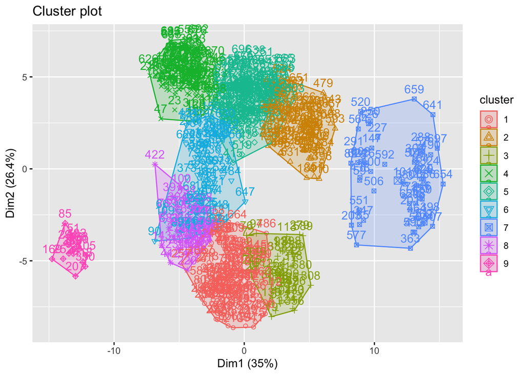

```r
fviz_cluster(mod_km9,
             data = weather_norm
             )
```

# 4 Submitting your work

Once you have developed all the code and answers, make sure to Render this quarto file.

**Notes on rendering**:

- Make sure to render your work and inspect how the final html look like.
- If it does not look professional for whatever reason, then fix the issue, re-render it, recheck.
- Only send me your work once your html file looks professional.
  - **DO NOT** delete the file’s heading levels (# and ##). They set up the proper heading 1 and 2 levels, and I use them to guide my grading.
  - If a given chunk is also outputting warnings or messages, inhibit this behavior by changing the chunk options `message` and `warning` to `FALSE` (I’ll demo this in a moment).
  - If, after rendered, 2 lines of text are connected and you wish to “break line” between them, add 2 extra spaces after the first one (I’lld demo this in a moment).

After rendering, an .html file will be created on your `code` folder.

Rename this file to `Assignment-05-kmeans-LASTNAME.html`.

For ex., mine would be `Assignment-05-kmeans-Bastos.html`.

Submit your work by uploading the **html** file to **eLC Assignment #5 - K-means** by Monday March 2nd 11:59 pm.